# 第三章：数据可视化 1: ggplot2

#### **课外教程参考**

- **雷达图（fmsb / ggradar 综合）**：[Datanovia · Radar Chart in R](https://www.datanovia.com/en/blog/beautiful-radar-chart-in-r-using-fmsb-and-ggplot-packages/)
- **雷达图（ggradar：ggplot 风格）**：[Radar chart with ggradar](https://r-graph-gallery.com/web-radar-chart-with-R.html)
- **雷达图（fmsb：基础与多组叠加）**：[Spider/Radar chart (fmsb)](https://r-graph-gallery.com/spider-or-radar-chart.html)

**© 华东师范大学 社会发展学院 人口研究所** | [**DAWN 研究组**](https://dawn-ecnu.github.io) | yzliu@soci.ecnu.edu.cn

课程负责人：刘贇喆 本章作者：刘贇喆 | 蒋娴静

最后更新：2026年03月19日 构建环境：R version 4.5.2 (2025-10-31)

[CC BY-NC-SA 4.0](https://creativecommons.org/licenses/by-nc-sa/4.0/deed.zh) 回到顶部

##### 箱线图

###### **3.6 箱线图：离群值与分布**

基础概念

**箱线图**（Boxplot），又称“箱须图”，是统计学中用于展示**数据分布特征**的常用图形，尤其适合同时呈现**离散程度**与**离群值**信息。它基于“五数概括法”（Five-number summary），用少量图形元素概括一组数据的整体结构。

**1. 适用场景**

- **多组分布对比**：  
  当需要比较多个类别（如不同大洲）的分布差异时，箱线图比多张直方图更节省空间且更易横向比较。
- **离群值检测**：  
  快速定位远离主体分布的异常观测点（Outliers），为后续核查数据质量或解释极端个案提供线索。

**2. 如何阅读箱线图？**

将数据视为已按数值大小排序，箱线图主要呈现以下关键位置：

- **箱体**（Box）：  
  表示数据的**中间 50%**，范围为第 25% 分位数($Q_1$) 到第 75% 分位数 ($Q_3$)。箱体越高，说明中间一半数据的波动越大。
- **中位线**（Median）：  
  箱体中的粗线，表示中位数 $Q_2$（50% 分位数）
- **胡须**（Whiskers）：  
  从箱体上下延伸的线段，表示“非异常范围”的边界；常用规则为 $[Q_1-1.5\times IQR,\; Q_3+1.5\times IQR]$（IQR 为四分位距）
- **离群点**（Outliers）：  
  落在胡须之外的点，提示其数值相对整体分布较为极端（可能是异常，也可能是具有解释价值的极端个案）

基础 · 代码实战

使用 `gapminder` 2007 年数据绘制基础箱线图，用于快速比较**各大洲预期寿命的分布差异**。

**代码逻辑**：

Step 1 **筛选截面数据**（2007 年）  
从 `gapminder` 中筛选 `year == 2007`，得到用于箱线图比较的单年截面数据 `data_box`。

Step 2 **设定映射关系**（类别 × 数值）  
在 `ggplot()` 中将 `continent` 映射到 `x`（分类轴）、将 `lifeExp` 映射到 `y`（连续轴），从而把“洲际分组”与“寿命水平”绑定到同一张图的坐标框架。

Step 3 **调用箱线图几何对象并完成五数概括绘制**  
叠加 `geom_boxplot()`：该函数会基于每个 `continent` 组内数据自动计算中位数与四分位数，并绘制箱体、胡须以及离群点（默认按 1.5×IQR 规则识别）。

Step 4 **补充文本信息与统一主题风格**  
用 `labs()` 添加标题、说明与轴标签，明确图形元素含义；最后使用 `theme_minimal()` 降低背景干扰，突出分布差异。

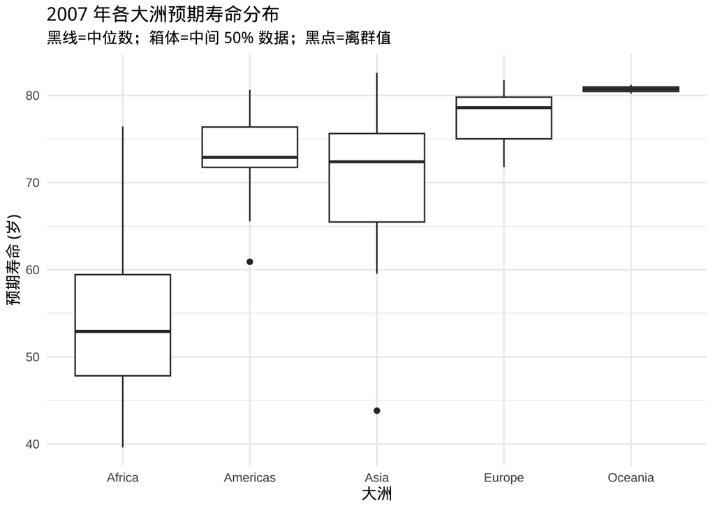

```r
# 0. 数据筛选
library(tidyverse)
library(gapminder)

data_box <- gapminder %>%
  filter(year == 2007)

# 1. 绘图初始化
ggplot(
  data = data_box,
  mapping = aes(
    x = continent,  # x轴：分类变量（大洲）
    y = lifeExp     # y轴：连续变量（预期寿命）
  )
) +
  # 2. 几何层：箱线图
  # 自动计算中位数、四分位数、IQR，并绘制箱体/胡须/离群点
  geom_boxplot() +

  # 3. 标签与主题
  labs(
    title    = "2007 年各大洲预期寿命分布",
    subtitle = "黑线=中位数；箱体=中间 50% 数据；黑点=离群值",
    x        = "大洲",
    y        = "预期寿命 (岁)"
  ) +
  theme_minimal()
```

进阶 · 代码实战

为更细致地呈现**分布形态**与**时间演变**，本节使用 **分面小提琴图**（Faceted Violin Plot） 展示 `lifeExp` 在不同大洲的分布轮廓。小提琴图基于**核密度估计**（KDE），能够在同一张图中同时观察各组的**集中区间、偏态**与**可能的多峰结构**。

**代码逻辑**：

Step 1 **环境与字体：统一中文显示口径**  
加载 `tidyverse` 与 `gapminder`，并用 `showtext` 注册 `Noto Sans SC` 到 `family = "my_font"`；随后启用 `showtext_auto()`，保证标题、坐标轴与分面条带可稳定显示中文。

Step 2 **数据筛选：三期截面对照 + 分面顺序固定**  
从 `gapminder` 中筛选 `1952 / 1977 / 2007` 三个代表年份构成对照样本，并将 `year` 设为有序因子  
`factor(year, levels = c(1952, 1977, 2007))`，确保 `facet_wrap()` 分面按时间顺序排列。

Step 3 **美学映射：类别 × 分布变量 + 同色系边界强化**  
在 `ggplot()` 中将 `continent` 映射到 `x`（类别轴），将 `lifeExp` 映射到 `y`（连续变量）；同时将 `fill` 与 `colour` 都映射为 `continent`，使填充与轮廓保持同色系，增强小提琴边界的辨识度。

Step 4 **几何层：密度轮廓 + 中位数线**（读图锚点）  
使用 `geom_violin()` 绘制密度轮廓，并通过关键参数控制形态与可读性：  
- `trim = TRUE`：将密度裁剪到观测范围内（不向外延展）；  
- `draw_quantiles = 0.5`：在小提琴内部绘制中位数线，提供组内中心位置的参照；  
- `alpha` 与 `linewidth`：平衡填充强度与轮廓清晰度，减少遮挡。

Step 5 **分面布局：按年份分块以呈现时间演变**  
使用 `facet_wrap(~ year, ncol = 1)` 将三个年份按行排列，使同一大洲在不同年份的分布形态可纵向对照；并保持 `y` 轴共享尺度以支持跨年可比。

Step 6 **色盘与主题：统一视觉系统并减少冗余信息**  
采用 `scale_fill_brewer()` 与 `scale_colour_brewer()` 的 `Set2` 色盘统一配色；通过 `theme_minimal()` + `my_font` 系列设置统一排版风格，并关闭图例 `legend.position = "none"`（因 `x` 轴已直接标注大洲，避免重复）。

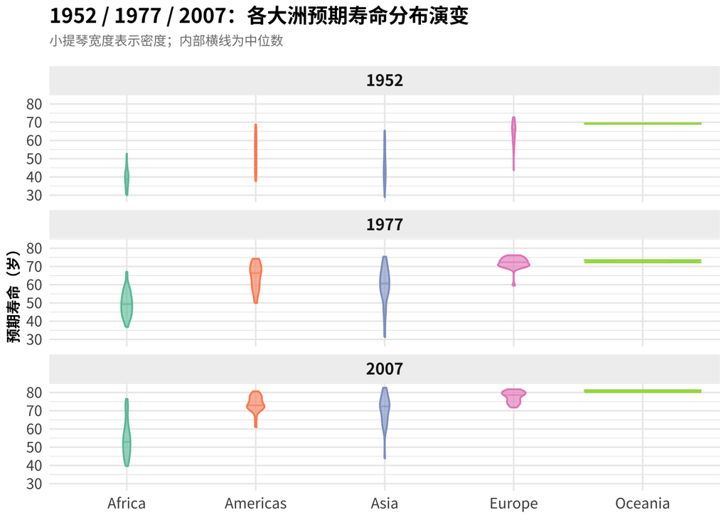

```r
# ==============================================================================
# 小提琴图（Violin Plot）：三期对比（1952 / 1977 / 2007）
# 目标：比较各大洲 lifeExp 的分布形态随时间的变化（密度轮廓 + 中位数线）
# ==============================================================================

library(tidyverse)
library(gapminder)
library(showtext)

# ------------------------------------------------------------------------------
# 0) 环境准备（字体：可跨平台稳定显示中文）
# ------------------------------------------------------------------------------
font_add_google(name = "Noto Sans SC", family = "my_font")
showtext_auto()
options(scipen = 9999)

# ------------------------------------------------------------------------------
# 1) 数据准备：筛选三个代表年份 + 年份设为有序因子（保证分面顺序）
# ------------------------------------------------------------------------------
data_violin <- gapminder %>%
  filter(year %in% c(1952, 1977, 2007)) %>%
  mutate(year = factor(year, levels = c(1952, 1977, 2007)))

# ------------------------------------------------------------------------------
# 2) 绘图：小提琴图（密度轮廓）+ 中位数线 + 分面（三行）
# ------------------------------------------------------------------------------
ggplot(
  data = data_violin,
  mapping = aes(
    x = continent,
    y = lifeExp,
    fill  = continent,   # 填充：区分大洲
    colour = continent   # 轮廓：与填充同色系，增强边界可读性
  )
) +
  geom_violin(
    alpha = 0.60,        # 透明度：避免颜色过重
    trim  = TRUE,        # 密度裁剪到观测范围（不外延）
    draw_quantiles = 0.5,# 在小提琴内部画中位数线
    linewidth = 0.60     # 轮廓线宽：更清晰的边界
  ) +
  facet_wrap(~ year, ncol = 1) +

  # 统一色盘
  scale_fill_brewer(palette = "Set2") +
  scale_colour_brewer(palette = "Set2") +

  labs(
    title    = "1952 / 1977 / 2007：各大洲预期寿命分布演变",
    subtitle = "小提琴宽度表示密度；内部横线为中位数",
    x        = NULL,
    y        = "预期寿命（岁）"
  ) +

  # 主题：与“my_font”体系保持一致
  theme_minimal() +
  theme(
    plot.title    = element_text(family = "my_font", face = "bold", size = 14, hjust = 0),
    plot.subtitle = element_text(family = "my_font", size = 9, color = "grey50",
                                 face = "italic", margin = margin(b = 12)),
    axis.title    = element_text(family = "my_font", face = "bold", size = 10),
    axis.text     = element_text(family = "my_font", size = 10),

    strip.background = element_rect(fill = "#f0f0f0", color = NA),
    strip.text       = element_text(family = "my_font", face = "bold", size = 11),

    legend.position  = "none"   # x 轴已显示大洲，不重复图例
  )
```

#### **图形解读：如何看懂“小提琴”？**

> 小提琴图本质上是**“镜像后的密度图”**（density 的左右镜像）。

阅读时重点关注两件事：**哪里最“胖”**、**尾部拖得多长**。

- **胖瘦**（Width）= **密度**（Density）
  - **最宽处**：该取值区间的国家最集中。
  - **细长处**：只有少数国家落在该区间，属于“尾部”或极端值。
- **形状对比**  
  例如 `Europe` 往往在较高寿命区间更“鼓”，而 `Africa` 更可能在较低寿命区间更“鼓”：  
  同一张图里就能看出不同大洲的寿命分布中心与不均衡结构。

**为什么 `Oceania` 看起来很奇怪？**

- **数据原因**：  
  在 `gapminder` 中，`Oceania` 只有 2 个国家（Australia、New Zealand）参与分布估计。
- **统计原因**：  
  小提琴图依赖核密度估计(KDE)与平滑。当样本量极少时，密度曲线不稳定，形状容易被平滑算法“撑开”，导致看起来像一条平直的宽带。

**警示**：  
当每组样本量很小（例如 < 5）时，小提琴图（或箱线图）都可能缺乏解释力。更稳妥的做法是使用**抖动散点图**（Jitter Plot）直接展示观测点，必要时再配合均值/中位数标记 (参考下列代码)

进阶代码 · 抖动散点图

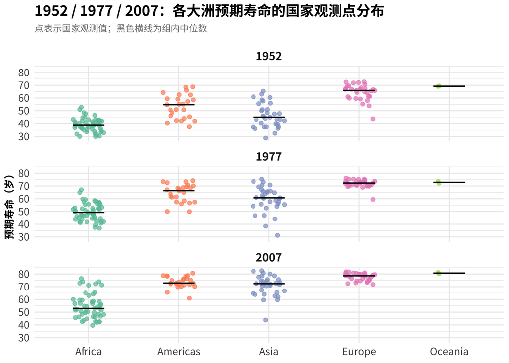

```r
# ==============================================================================
# 抖动散点图（Jitter Plot）：三期对比（1952 / 1977 / 2007）
# 目标：直接呈现“国家层级观测点”，并用中位数线辅助比较组间中心位置
# ==============================================================================

library(tidyverse)
library(gapminder)
library(showtext)

# ------------------------------------------------------------------------------
# 0) 环境准备（字体：可跨平台稳定显示中文）
# ------------------------------------------------------------------------------
font_add_google(name = "Noto Sans SC", family = "my_font")
showtext_auto()
options(scipen = 9999)

# ------------------------------------------------------------------------------
# 1) 数据准备：筛选三个代表年份 + 年份设为有序因子（保证分面顺序）
# ------------------------------------------------------------------------------
data_jitter <- gapminder %>%
  filter(year %in% c(1952, 1977, 2007)) %>%
  mutate(year = factor(year, levels = c(1952, 1977, 2007)))

# ------------------------------------------------------------------------------
# 2) 绘图：抖动散点（国家点）+ 中位数参考线 + 分面（三行）
# ------------------------------------------------------------------------------
ggplot(
  data = data_jitter,
  mapping = aes(
    x = continent,
    y = lifeExp,
    colour = continent   # 颜色：区分大洲
  )
) +
  geom_jitter(
    width  = 0.18,       # x 方向轻微抖动：缓解重叠
    height = 0,          # y 方向不抖动：保持数值真实
    alpha  = 0.70,
    size   = 1.60
  ) +
  # 组内中位数：作为“中心位置”的参考（对偏态分布更稳健）
  stat_summary(
    fun  = median,
    geom = "crossbar",
    width = 0.35,
    linewidth = 0.25,
    colour = "black"
  ) +
  facet_wrap(~ year, ncol = 1) +

  # 统一色盘：与前述分布图一致（Set2）
  scale_colour_brewer(palette = "Set2") +

  labs(
    title    = "1952 / 1977 / 2007：各大洲预期寿命的国家观测点分布",
    subtitle = "点表示国家观测值；黑色横线为组内中位数",
    x        = NULL,
    y        = "预期寿命（岁）"
  ) +

  theme_minimal() +
  theme(
    plot.title    = element_text(family = "my_font", face = "bold", size = 14, hjust = 0),
    plot.subtitle = element_text(family = "my_font", size = 9, color = "grey50",
                                 face = "italic", margin = margin(b = 12)),
    axis.title    = element_text(family = "my_font", face = "bold", size = 10),
    axis.text     = element_text(family = "my_font", size = 10),

    strip.text    = element_text(family = "my_font", face = "bold", size = 11),
    legend.position = "none"  # x 轴已写明大洲；避免重复图例
  )
```

#### **课外教程参考**

- **箱线图**：[R Graph Gallery · Boxplot (ggplot2)](https://r-graph-gallery.com/boxplot.html)
- **小提琴图**：[R Graph Gallery · Grouped violin plot (ggplot2)](https://r-graph-gallery.com/violin_grouped_ggplot2.html)
- **抖动/条带图**：[Datanovia · ggplot2 Stripchart](https://www.datanovia.com/en/lessons/ggplot-stripchart/)

**© 华东师范大学 社会发展学院 人口研究所** | [**DAWN 研究组**](https://dawn-ecnu.github.io) | yzliu@soci.ecnu.edu.cn

课程负责人：刘贇喆 本章作者：刘贇喆 | 蒋娴静

最后更新：2026年03月19日 构建环境：R version 4.5.2 (2025-10-31)

[CC BY-NC-SA 4.0](https://creativecommons.org/licenses/by-nc-sa/4.0/deed.zh) 回到顶部

##### 流向图

###### **3.7 流向图：路径与流量**

基础概念

**流向图**（Sankey Diagram / Alluvial Plot）用于展示多个**分类变量**之间的**路径结构**与**流量分配**。图中每一列为一个阶段（axis），每个矩形为一个类别节点（stratum）；连接节点的“流”（alluvium/flow）宽度编码**数量**或**权重**，便于在同一图中同时观察**组成**、**分流**与**汇聚**。

**1. 适用场景**

- **路径追踪**：  
  观察个体或样本如何从初始类别，经过若干阶段，流向最终结果  
  （如：分层 → 分组 → 结局）。
- **结构对比**：  
  对比不同起点类别在后续阶段的分流差异  
  （谁更集中，谁更分散）。
- **状态转换**：  
  展示状态/标签在多阶段下的变迁  
  （如：前-中-后期的类别迁移）。

**2. 如何阅读流向图？**

- **节点宽度**（Stratum size）：  
  表示该阶段某类别的总量。
- **流线宽度**（Flow width）：  
  表示从上一步某类别流向下一步某类别的数量或权重。
- **分叉与汇聚**（Split/Merge）：  
  分叉表示内部异质性（同一类别流向多个后续类别）；汇聚表示不同来源在后续阶段汇合。
- **颜色映射**：  
  常按起点类别着色，便于追踪同一来源在各阶段的走向。

**3. 核心工具与函数**

`ggplot2` 体系下常用 `ggalluvial` 绘制流向图，其核心几何对象为：

> **`geom_alluvium()`**（绘制流线）  
> **`geom_stratum()`**（绘制节点）  
> **`geom_text(stat = "stratum")`**（节点标签）

基础 · 代码实战

使用内置的 `Titanic` 数据，展示“舱位等级 → 性别 → 是否幸存”的路径结构（以人数为权重）。

#### 延伸阅读：Titanic 事件与示例数据

- **事件背景**：  
  泰坦尼克号（RMS Titanic）是英国白星航运公司建造的远洋客轮。1912 年 4 月 15 日凌晨，泰坦尼克号在北大西洋航行途中撞上冰山后沉没，造成大量人员伤亡，成为现代航海史上最著名的海难事件之一。
- **数据是什么**：  
  R 语言内置的 `Titanic` 数据集是对该事件乘客信息的一个**汇总频数表**（contingency table）。它并非逐个乘客的明细记录，而是按类别组合统计人数。
- **数据包含什么**：  
  数据以四个分类维度组织：`Class`（舱位等级）、`Sex`（性别）、`Age`（成人/儿童）、`Survived`（是否幸存）；对应的 `Freq` 表示该类别组合下的**人数**。

**代码逻辑**：

Step 1 **准备数据与绘图环境**（最小依赖）  
加载 `ggalluvial`，并将内置的 `Titanic` 频数表转换为数据框 `titanic_df`。其中 `Freq` 表示每个类别组合对应的**人数权重**。

Step 2 **设定多阶段轴映射**（axis1/axis2/axis3）  
在 `aes()` 中依次指定 `axis1 = Class`、`axis2 = Sex`、`axis3 = Survived`，并用 `y = Freq` 定义流线宽度的度量口径（人数）。

Step 3 **绘制流线与节点**（最小作图单元）  
使用 `geom_alluvium()` 绘制流线，并以 `fill = Class` 按起点舱位着色以便追踪同一来源的分流；再用 `geom_stratum()` 绘制每一列的节点矩形，表示该阶段各类别的总量。

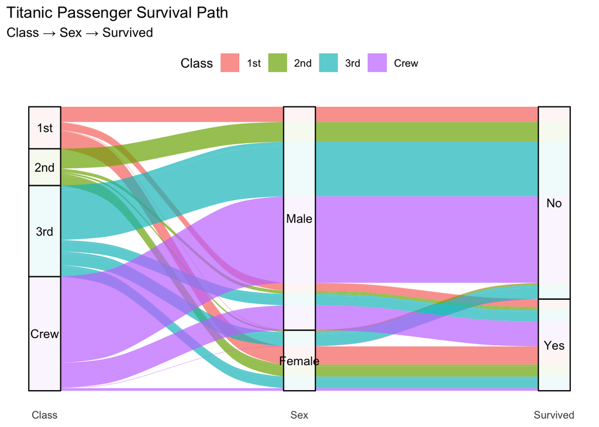

```r
# ==============================================================================
# 基础：流向图（Class → Sex → Survived）
# 目标：用流线宽度表示人数，追踪不同舱位在性别与幸存结局上的分流
# ==============================================================================

library(tidyverse)   # 数据处理与 ggplot2（本例主要用到 ggplot2）
library(ggalluvial)  # ggplot2 生态下的流向图/桑基图扩展包

# ------------------------------------------------------------------------------
# Step 1. 数据准备：Titanic 为四维列联表（频数表），Freq 表示人数
# 说明：流向图通常需要“分类维度 + 权重（y）”的数据结构
# ------------------------------------------------------------------------------
titanic_df <- as.data.frame(Titanic)

# ------------------------------------------------------------------------------
# Step 2. 建立坐标映射：
# - axis1/axis2/axis3：定义三列“阶段轴”（从左到右的类别序列）
# - y = Freq：定义流线宽度的度量口径（人数）
# ------------------------------------------------------------------------------
ggplot(
  data = titanic_df,
  mapping = aes(
    axis1 = Class,     # 第 1 阶段：舱位等级
    axis2 = Sex,       # 第 2 阶段：性别
    axis3 = Survived,  # 第 3 阶段：是否幸存
    y     = Freq       # 流量/权重：该路径上的人数
  )
) +
  # ----------------------------------------------------------------------------
  # Step 3. 绘制“流线”：
  # - fill = Class：按起点舱位着色，便于追踪同一来源在后续阶段的分流
  # - alpha：透明度，减轻遮挡
  # - width：控制各阶段柱与流线的横向厚度
  # ----------------------------------------------------------------------------
  geom_alluvium(aes(fill = Class), alpha = 0.7, width = 1/8) +

  # ----------------------------------------------------------------------------
  # Step 4. 绘制“节点”（每一列的矩形）：
  # 节点高度（宽度方向的总量）由 y = Freq 聚合得到
  # ----------------------------------------------------------------------------
  geom_stratum(width = 1/8, alpha = 0.9) +

  # ----------------------------------------------------------------------------
  # Step 5. 添加节点标签：
  # stat = "stratum"：在每个节点中心生成统计结果
  # after_stat(stratum)：提取节点类别名作为标签
  # ----------------------------------------------------------------------------
  geom_text(
    stat = "stratum",
    aes(label = after_stat(stratum)),
    size = 3.6
  ) +

  # ----------------------------------------------------------------------------
  # Step 6. 固定阶段顺序与留白：
  # limits：锁定从左到右的阶段顺序，避免默认排序导致不确定性
  # expand：控制左右边缘留白，避免图形贴边
  # ----------------------------------------------------------------------------
  scale_x_discrete(
    limits = c("Class", "Sex", "Survived"),
    expand = c(0.05, 0.05)
  ) +

  # ----------------------------------------------------------------------------
  # Step 7. 主题与版式：减少视觉干扰
  # - 关闭 y 轴文字与网格：流向图主要关注路径结构，y轴刻度往往非必要
  # - 图例置顶：便于快速识别舱位颜色
  # ----------------------------------------------------------------------------
  theme_minimal() +
  theme(
    legend.position = "top",
    axis.text.y     = element_blank(),
    axis.title.y    = element_blank(),
    panel.grid      = element_blank()
  ) +

  # ----------------------------------------------------------------------------
  # Step 8. 标题与图例标题
  # ----------------------------------------------------------------------------
  labs(
    title    = "Titanic Passenger Survival Path",
    subtitle = "Class → Sex → Survived",
    fill     = "Class"
  )
```

#### **图形解读：怎么读流向图？**

流向图的核心读法是：先看**节点总量**，再沿着颜色追踪**分流路径**（宽度代表人数）。

- **起点结构**：左侧 `Class` 节点宽度对比，可读出各舱位总体人数构成。
- **性别分流**：中间 `Sex` 节点处的分叉，展示不同舱位内部的性别构成差异。
- **结局差异**：右侧 `Survived` 节点处的流向宽度对比，可用于判断不同路径的幸存与遇难差异。

**结合本图的快速观察**（Class → Sex → Survived）：

- **总体结局**：右侧 `No` 的节点明显更宽，说明总体上遇难人数多于幸存人数。
- **性别差异**：从 `Sex` 到 `Survived` 的流线对比可见，`Female → Yes` 的流线相对更粗，而 `Male → No` 更突出，反映出明显的性别差异。
- **舱位差异**：按颜色追踪可见，`1st` 流向 `Yes` 的比例相对更高；`3rd` 与 `Crew` 流向 `No` 的部分更显著，提示不同舱位在幸存结果上存在差异。

进阶代码

**代码逻辑**：

Step 1 **字体与绘图环境初始化**（中文渲染）  
加载 `showtext` 并注册 `Noto Sans SC` 字体，将其设为全局字体 `my_font`，确保后续标题与节点标签可稳定显示中文。

Step 2 **数据聚合与口径构造**（路径占比）  
将 `Titanic` 频数表转换为数据框，并按 `Class × Sex × Survived` 聚合为一条条“路径”记录，得到对应人数 `Freq`。同时构造 `prop = Freq / sum(Freq)` 作为**路径占比**，用于后续透明度映射；并将各类别重编码为中文标签，统一因子顺序以保证图面稳定。

Step 3 **设定多阶段轴映射**（axis1/axis2/axis3）  
在 `aes()` 中指定 `axis1 = Class`、`axis2 = Sex`、`axis3 = Survived`，并用 `y = Freq` 定义流线宽度的度量口径（人数）。

Step 4 **颜色与透明度的双编码**（舱位 × 占比）

- 在 `geom_alluvium()` 中设置 `fill = Class`，并用 `ggsci` 色板为不同舱位/船员提供一致配色；
- 同时设置 `alpha = prop`，使占比越高的路径越不透明，占比越低的路径越透明，以增强结构对比。

Step 5 **节点与标签输出**（可读性）  
用 `geom_stratum()` 绘制各阶段节点，并使用浅色底 + 黑色描边提升对比；再用 `geom_text(stat="stratum")` 标注节点名称，字体设置为 `my_font` 以保证中文显示。

Step 6 **固定阶段顺序与主题排版**（稳定输出）  
使用 `scale_x_discrete(limits = ...)` 固定阶段顺序（舱位 → 性别 → 结局）并设置中文轴标签；最后用 `theme_minimal()` 简化背景并隐藏 y 轴元素，使读者聚焦于路径结构与分流差异。

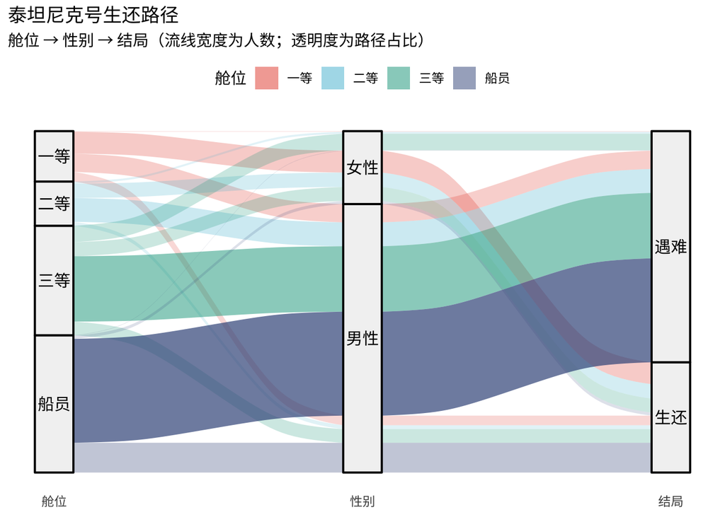

```r
# ==============================================================================
# 进阶：流向图（舱位 → 性别 → 结局）
# 升级点：
# 1) 使用 ggsci 配色区分舱位/船员
# 2) 用透明度编码“路径占比”（占比越高越不透明）
# 3) 使用 showtext + 中文字体，并用中文标签输出
# ==============================================================================

# ------------------------------------------------------------------------------
# 0) 字体环境（中文显示）
# ------------------------------------------------------------------------------
library(showtext)
font_add_google(name = "Noto Sans SC", family = "my_font")
showtext_auto()
options(scipen = 9999)

# ------------------------------------------------------------------------------
# 1) 依赖加载
# ------------------------------------------------------------------------------
library(tidyverse)
library(ggalluvial)
library(ggsci)

# ------------------------------------------------------------------------------
# 2) 数据准备：按「Class × Sex × Survived」聚合（避免 Age 造成重复流线）
#    - prop：路径占比（用于透明度映射）
# ------------------------------------------------------------------------------
titanic_adv <- as.data.frame(Titanic) %>%
  group_by(Class, Sex, Survived) %>%
  summarise(Freq = sum(Freq), .groups = "drop") %>%
  mutate(
    prop = Freq / sum(Freq),  # 路径占比：越高越不透明

    # 中文标签（用于节点与图例）
    Class = recode(Class,
                   "1st"  = "一等",
                   "2nd"  = "二等",
                   "3rd"  = "三等",
                   "Crew" = "船员"),
    Sex = recode(Sex,
                 "Male"   = "男性",
                 "Female" = "女性"),
    Survived = recode(Survived,
                      "Yes" = "生还",
                      "No"  = "遇难")
  ) %>%
  mutate(
    # 固定顺序：保证图面稳定可控
    Class    = factor(Class, levels = c("一等", "二等", "三等", "船员")),
    Sex      = factor(Sex, levels = c("女性", "男性")),
    Survived = factor(Survived, levels = c("遇难", "生还"))
  )

# ------------------------------------------------------------------------------
# 3) 配色：ggsci 色板（为不同舱位/船员提供一致且易区分的颜色）
# ------------------------------------------------------------------------------
class_cols <- ggsci::pal_npg()(length(levels(titanic_adv$Class)))
names(class_cols) <- levels(titanic_adv$Class)

# ------------------------------------------------------------------------------
# 4) 绘图：流线颜色 = 舱位；流线透明度 = 路径占比
# ------------------------------------------------------------------------------
ggplot(
  data = titanic_adv,
  mapping = aes(
    axis1 = Class,      # 第 1 阶段：舱位
    axis2 = Sex,        # 第 2 阶段：性别
    axis3 = Survived,   # 第 3 阶段：结局
    y     = Freq        # 流线宽度：人数
  )
) +
  # 流线：颜色按舱位；透明度按“路径占比”
  geom_alluvium(
    aes(fill = Class, alpha = prop),
    width = 1/8
  ) +
  # 节点：统一浅色底 + 黑色描边，提升中文标签可读性
  geom_stratum(
    width = 1/8,
    fill = "grey95",
    colour = "black",
    linewidth = 0.7
  ) +
  # 节点标签：直接显示中文类别
  geom_text(
    stat = "stratum",
    aes(label = after_stat(stratum)),
    family = "my_font",
    size = 4
  ) +
  # 固定阶段顺序 + 中文轴标题
  scale_x_discrete(
    limits = c("Class", "Sex", "Survived"),
    labels = c("Class" = "舱位", "Sex" = "性别", "Survived" = "结局"),
    expand = c(0.05, 0.05)
  ) +
  # 舱位配色（ggsci）
  scale_fill_manual(values = class_cols, name = "舱位") +
  # 透明度映射：占比越高越不透明（不单独显示 alpha 图例）
  scale_alpha_continuous(range = c(0.15, 0.7), guide = "none") +
  # 标题与主题（中文字体）
  labs(
    title    = "泰坦尼克号生还路径",
    subtitle = "舱位 → 性别 → 结局（流线宽度为人数；透明度为路径占比）"
  ) +
  theme_minimal() +
  theme(
    text = element_text(family = "my_font"),
    legend.position = "top",
    axis.title.y    = element_blank(),
    axis.text.y     = element_blank(),
    panel.grid      = element_blank()
  )
```

#### **课外教程参考**

- **流向图**：[Alluvial Plots in ggplot2](https://cran.r-project.org/web/packages/ggalluvial/vignettes/ggalluvial.html)
- **桑基图**：[R Graph Gallery · ggsankey](https://r-charts.com/flow/sankey-diagram-ggplot2/#google_vignette)
- **ggsankeyfier**：[ggsankeyfier](https://pepijn-devries.github.io/ggsankeyfier/)

**© 华东师范大学 社会发展学院 人口研究所** | [**DAWN 研究组**](https://dawn-ecnu.github.io) | yzliu@soci.ecnu.edu.cn

课程负责人：刘贇喆 本章作者：刘贇喆 | 蒋娴静

最后更新：2026年03月19日 构建环境：R version 4.5.2 (2025-10-31)

[CC BY-NC-SA 4.0](https://creativecommons.org/licenses/by-nc-sa/4.0/deed.zh) 回到顶部

##### 山峦图

###### **3.8 山峦图：脊线与层叠**

基础概念

**山峦图**（Ridgeline Plot），又称**“脊线图”**，是一种用于展示**多个分类组别**下连续变量**数据分布**的图形。它通过将多个核密度估计曲线（KDE）在垂直方向上错位重叠排列，形似连绵起伏的山脉，从而在有限的垂直空间内高效对比**多组数据的分布形态**与**演变趋势**。

**1. 适用场景**

- **类别间的形态对比**：  
  在垂直空间受限时，比较多个类别（如不同大洲、不同班级）的密度分布。相比于将所有密度曲线画在同一水平基线上造成的严重遮挡，山峦图的错位层叠设计更具可读性。
- **多组分布的时间演变**：  
  展示某一连续指标随时间（如不同年份、月份）推移的分布变化趋势，山峦的“整体推移”能直观反映趋势的演进。
- **模式与异常识别**：  
  快速识别各组分布的峰值特征（单峰/双峰）、偏度（左偏/右偏）以及长尾特征。

**2. 如何阅读山峦图？**

将图形视为多条独立核密度曲线的垂直排布，主要呈现以下关键特征：

- **山峰位置**（Peaks）：  
  对应数据分布的**众数**或最集中的取值区间。山峰越靠右，说明该组在 x 轴上的整体水平越高。
- **山体形态**（Shape/Spread）：  
  反映数据的**离散程度**。山体越宽平，说明数据波动越大；越陡峭，说明数据越集中。
- **重叠区域**（Overlap）：  
  相邻曲线的重叠部分展示了组间数据取值的交集。重叠越少，说明组间差异越显著。

**3. 核心工具与函数**

绘制山峦图需要配合第三方扩展包 `ggridges` 使用，其核心几何对象函数为： > **`geom_density_ridges()`** > 注：需要提前安装并读取 `ggridges`

基础 · 代码实战

使用 `gapminder` 2007 年数据绘制基础山峦图，用于直观比较**各大洲预期寿命的密度分布轮廓**。

**代码逻辑**：

Step 1 **准备数据与绘图环境**（加载扩展包）  
除了 `tidyverse` 与 `gapminder`，需额外加载 `ggridges` 包；筛选 `year == 2007` 得到用于对比的单年截面数据 `data_ridge`。

Step 2 **设定映射关系**（连续 × 类别）  
在 `ggplot()` 中将 `lifeExp` 映射到 `x`（连续轴，决定山底的宽度）、将 `continent` 映射到 `y`（分类轴，决定各座山的基线高度），同时将 `continent` 映射到 `fill`（用颜色区分不同山体）。 > **注意**：山峦图的 xy 映射方向通常与箱线图相反。

Step 3 **调用脊线几何对象并控制层叠**  
叠加 `geom_density_ridges()`：设置 `alpha = 0.7` 增加透明度以透视被遮挡的山体，并通过 `scale = 1.5` 参数适度放大山体的高度倍率（形成错位重叠的“山峦感”），同时加上白色描边区分边界。

Step 4 **补充文本信息与统一主题风格**  
用 `labs()` 添加基本的标题与轴标签（为保证基础出图的稳定性，暂用英文避免乱码）；最后使用 `theme_minimal()` 降低背景干扰，并通过 `theme(legend.position = "none")` 关闭不必要的图例（因 y 轴已标明大洲类别，保留图例属于信息冗余）。

> 注： 因为**大洋洲**(Oceania)数据中只有两个国家，在本图中暂时剔除

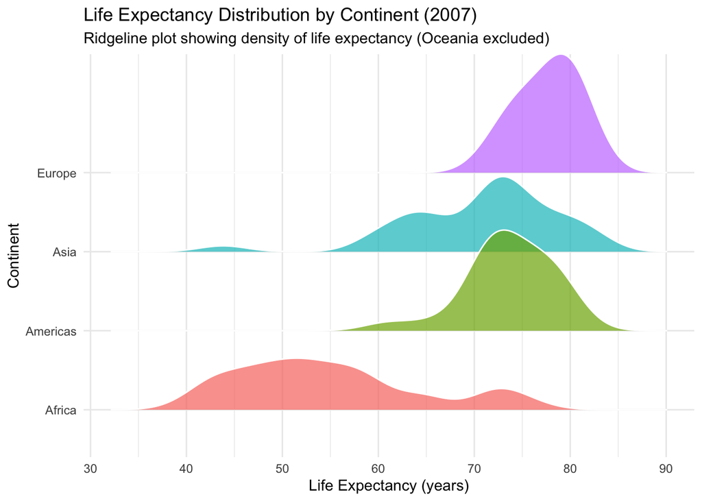

```r
# ==============================================================================
# 基础：山峦图（continent × lifeExp）
# 目标：用层叠密度曲线比较各大洲预期寿命的密度分布轮廓
# ==============================================================================

# -----------------------------
# Step 1. 准备数据与绘图环境
# -----------------------------
library(tidyverse)
library(gapminder)
library(ggridges)  # 绘制山峦图的核心包

# 筛选 2007 年截面数据，并剔除大洋洲 (因其样本量极小，不适合进行密度估计)
data_ridge <- gapminder %>%
  filter(year == 2007, continent != "Oceania")

# -----------------------------
# Step 2 & 3 & 4. 绘图构建
# -----------------------------
ggplot(
  data = data_ridge,
  mapping = aes(
    x = lifeExp,     # x轴 (连续轴)：决定山底的宽度
    y = continent,   # y轴 (分类轴)：决定各座山的基线高度
    fill = continent # 填充色：用不同颜色区分各大洲
  )
) +
  # Step 3. 调用脊线几何对象并控制层叠
  # alpha: 增加透明度，使得被遮挡的山体轮廓依然可见
  # scale: 控制山体的高度倍率，适度放大形成错位重叠的“山峦感”
  geom_density_ridges(alpha = 0.7, scale = 1.5, color = "white") +

  # Step 4. 补充文本信息与统一主题风格 (基础图形暂用英文避免乱码)
  labs(
    title    = "Life Expectancy Distribution by Continent (2007)",
    subtitle = "Ridgeline plot showing density of life expectancy (Oceania excluded)",
    x        = "Life Expectancy (years)",
    y        = "Continent"
  ) +

  # 使用极简主题，并关闭图例 (因为 y 轴已经标明了大洲，保留图例属于信息冗余)
  theme_minimal() +
  theme(legend.position = "none")
```

#### **图形解读：怎么读山峦图？**

> 山峦图本质上是**“垂直错位重叠的核密度估计曲线”**（KDE）。

阅读时重点关注两个核心维度：**山峰的水平位置**与**山体的宽窄起伏**。

- **山峰位置**（Position） = **集中水平**（Central Tendency）
  - **山峰靠右**：说明该组数据的整体取值较高（如：预期寿命更长）。
  - **山峰靠左**：说明该组数据的整体取值较低（如：预期寿命较短）。
- **山体形态**（Shape） = **分布结构**（Distribution Structure）
  - **陡峭且集中**：数据变异性小，组内差异小（即方差小，发展较为均衡）。
  - **宽平或多峰**（Multimodal）：数据内部异质性强，提示组内可能存在明显的分层或极化现象。

**从图中可直接读出的主要发现 (Findings)：**

- **Europe（欧洲）**：分布最为集中且山峰最靠右，呈典型的单峰结构。表明该大洲国家间预期寿命普遍较高，且内部差异极小。
- **Africa（非洲）**：整体分布最靠左，且山体极为宽阔（甚至隐约可见双峰）。表明其预期寿命总体偏低，且洲内国家间的健康水平存在极大的不均衡。
- **Asia（亚洲）**：呈现明显的“多峰”与“长左尾”特征，跨度极大。提示亚洲内部存在强烈的异质性：既有接近欧洲的高寿命国家群体，也存在部分健康水平极低的极端值国家。

**补充说明**：  
图中排除了 `Oceania`（大洋洲）。在 `gapminder` 截面数据中该洲仅有 2 个国家，样本量极小。强行对其拟合密度曲线不仅**缺乏统计意义**，更会导致山体形态被平滑算法严重扭曲。这提醒我们：任何密度分布图的绘制都必须建立在充足的样本支持之上。

进阶 · 代码实战

为更细致地呈现数据的**分布特征**与**跨时空演化**，本节将基础山峦图升级为**“多色阶地毯式山峦图”**（Gradient Ridgeline with Rugs）。针对 `ggplot2` 默认单一图层仅能承载一种填充色阶的底层限制，本代码引入 `ggnewscale` 包实现多重标度映射：为各大洲分配独立的渐变色盘（如亚洲为紫、欧洲为蓝）。同时，图表融合了基于分位数的**中位数标注**与底层的**地毯图**（Rug Plot），实现了宏观趋势与微观颗粒度的同步可视化。

**代码逻辑**：

Step 1 **数据清洗与因子优化**（跨时代截面）  
加载 `tidyverse`、`ggridges` 及核心扩展包 `ggnewscale`。通过 `filter` 提取 1952 与 2007 年截面数据。关键操作在于使用 `fct_drop()` 剔除无效观测值的因子层级，并配合 `scale_y_discrete(expand = ...)` 参数，严格控制 Y 轴边缘留白，使大洲间的垂直间距更趋紧凑。

Step 2 **多重标度叠加映射**（ggnewscale）  
通过循环叠加逻辑，为每个大洲单独调用 `geom_density_ridges_gradient()`。每完成一个大洲的颜色定义后，插入 `new_scale_fill()` 函数。该操作可重置绘图引擎的填充色映射，从而允许在同一坐标系内并存多套完全独立的渐变色阶。

Step 3 **透明度与色阶注入**（alpha 与 scale）  
由于渐变几何对象会屏蔽全局 `alpha` 参数，本方案采用**“色盘注入法”**：利用 `scales::alpha()` 直接对底层色板进行 0.4 透明度处理。这不仅赋予了山体通透感，还确保了背景网格线在重叠区域清晰可见。此外，将 `scale` 提升至 4.5，强制独立渲染的山体产生错位重叠效果。

Step 4 **统计标注与地毯映射**（Rug Plot）  
- **中位数可视化**：开启 `quantile_lines` 自动渲染分位线，并利用 `geom_text()` 在各组中点位置静态度量数值（精确至 0.1），强化信息传达的精准度。 - **分布颗粒度**：启用 `jittered_points` 映射原始观测值，利用竖线形状 `|` 和垂直位移 `yoffset` 将散点平移至山体基线下方，形成紧凑的“地毯”效应，揭示核密度曲线背后的真实样本点分布。

Step 5 **学术主题定制**  
应用 `facet_wrap` 实现跨时代对比。在 `theme` 层级中，加密 X 轴主刻度间距（步长为 10），并采用硬朗的网格边框与 `dotted` 虚线辅助线，提升图形的工程质感与学术规范性。

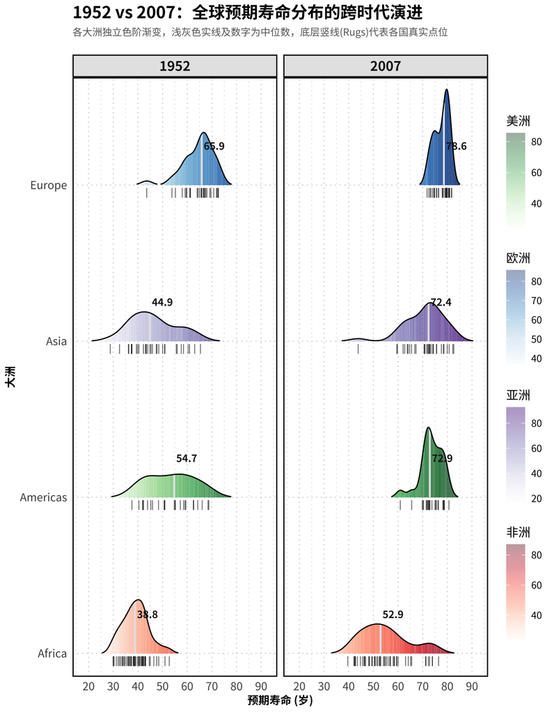

```r
# ==============================================================================
# 图形构建：多色阶地毯式山峦图（Faceted Gradient Ridgeline Plot with Rugs）
# 核心技术：核密度估计 (KDE)、多重 Fill 标度映射 (ggnewscale)、透明度色阶注入
# ==============================================================================

# 1. 环境初始化与全局字体设定
library(showtext)
font_add_google(name = "Noto Sans SC", family = "my_font")
showtext_auto()
options(scipen = 9999)

# 2. 依赖加载与数据预处理
library(tidyverse)
library(gapminder)
library(ggridges)
library(ggnewscale)

data_adv <- gapminder %>%
  filter(year %in% c(1952, 2007), continent != "Oceania") %>%
  mutate(
    year = factor(year, levels = c(1952, 2007)),
    # forcats::fct_drop 彻底清除被剔除数据的冗余因子层级，防止坐标轴出现异常留白
    continent = fct_drop(continent)
  )

# 统计预计算：获取各洲截面的中位数，并格式化为含1位小数的字符向量，供后续文本层调用
df_median <- data_adv %>%
  group_by(continent, year) %>%
  summarise(med_val = median(lifeExp, na.rm = TRUE), .groups = "drop") %>%
  mutate(med_label = sprintf("%.1f", med_val))

# 3. 初始化坐标系与全局参数
p <- ggplot(data_adv, aes(x = lifeExp, y = continent))

# 设定统一的核密度高度乘数 (scale)，强制分离的独立图层产生向上突破基线的视觉重叠
ridge_scale <- 4.5

# ------------------------------------------------------------------------------
# 4. 核心映射：利用 ggnewscale 突破单一图层限制，逐组分配独立渐变色带
# ------------------------------------------------------------------------------

# [图层 1] 非洲 (Africa)
p <- p +
  # geom_density_ridges_gradient: 允许 fill 属性沿 x 轴连续变量产生渐变映射
  geom_density_ridges_gradient(
    data = filter(data_adv, continent == "Africa"),
    aes(fill = after_stat(x)),
    scale = ridge_scale, rel_min_height = 0.01, color = "black",
    quantile_lines = TRUE, quantiles = 2, vline_color = "grey90", vline_width = 0.8, vline_linetype = "solid",
    jittered_points = TRUE, point_shape = "|", point_size = 3, point_alpha = 0.6,
    position = position_points_jitter(width = 0, height = 0, yoffset = -0.05)
  ) +
  # scale_fill_gradientn & scales::alpha:
  # 因 gradient 几何对象底层渲染屏蔽了全局 alpha，此处通过向输入色盘直接注入透明度来规避限制
  scale_fill_gradientn(
    colors = scales::alpha(RColorBrewer::brewer.pal(9, "Reds"), 0.4),
    name = "非洲"
  ) +
  # new_scale_fill: 释放当前的 fill 映射，为叠加下一图层做准备
  new_scale_fill()

# [图层 2] 美洲 (Americas)
p <- p +
  geom_density_ridges_gradient(
    data = filter(data_adv, continent == "Americas"),
    aes(fill = after_stat(x)),
    scale = ridge_scale, rel_min_height = 0.01, color = "black",
    quantile_lines = TRUE, quantiles = 2, vline_color = "grey90", vline_width = 0.8, vline_linetype = "solid",
    jittered_points = TRUE, point_shape = "|", point_size = 3, point_alpha = 0.6,
    position = position_points_jitter(width = 0, height = 0, yoffset = -0.05)
  ) +
  scale_fill_gradientn(
    colors = scales::alpha(RColorBrewer::brewer.pal(9, "Greens"), 0.4),
    name = "美洲"
  ) +
  new_scale_fill()

# [图层 3] 亚洲 (Asia)
p <- p +
  geom_density_ridges_gradient(
    data = filter(data_adv, continent == "Asia"),
    aes(fill = after_stat(x)),
    scale = ridge_scale, rel_min_height = 0.01, color = "black",
    quantile_lines = TRUE, quantiles = 2, vline_color = "grey90", vline_width = 0.8, vline_linetype = "solid",
    jittered_points = TRUE, point_shape = "|", point_size = 3, point_alpha = 0.6,
    position = position_points_jitter(width = 0, height = 0, yoffset = -0.05)
  ) +
  scale_fill_gradientn(
    colors = scales::alpha(RColorBrewer::brewer.pal(9, "Purples"), 0.4),
    name = "亚洲"
  ) +
  new_scale_fill()

# [图层 4] 欧洲 (Europe)
p <- p +
  geom_density_ridges_gradient(
    data = filter(data_adv, continent == "Europe"),
    aes(fill = after_stat(x)),
    scale = ridge_scale, rel_min_height = 0.01, color = "black",
    quantile_lines = TRUE, quantiles = 2, vline_color = "grey90", vline_width = 0.8, vline_linetype = "solid",
    jittered_points = TRUE, point_shape = "|", point_size = 3, point_alpha = 0.6,
    position = position_points_jitter(width = 0, height = 0, yoffset = -0.05)
  ) +
  scale_fill_gradientn(
    colors = scales::alpha(RColorBrewer::brewer.pal(9, "Blues"), 0.4),
    name = "欧洲"
  )

# ------------------------------------------------------------------------------
# 5. 统计标注、分面排版与出版级主题定制
# ------------------------------------------------------------------------------
p +
  # geom_text: 叠加预计算的中位数值，利用 nudge 控制物理偏移，确保文本浮于轴线之上
  geom_text(
    data = df_median,
    aes(x = med_val, y = continent, label = med_label),
    inherit.aes = FALSE,
    nudge_x = 0.8,
    nudge_y = 0.25,
    hjust = 0,
    size = 3.2,
    color = "grey10",
    family = "my_font",
    fontface = "bold"
  ) +

  # facet_wrap: 建立时间维度的平行对比切片
  facet_wrap(~ year) +

  # scale_x/y: 加密连续轴刻度，并严格压缩离散 Y 轴的上下边缘 (expand)，提升组间紧凑度
  scale_x_continuous(breaks = seq(20, 90, by = 10)) +
  scale_y_discrete(expand = expansion(mult = c(0.05, 0.23))) +

  labs(
    title    = "1952 vs 2007：全球预期寿命分布的跨时代演进",
    subtitle = "各大洲独立色阶渐变，浅灰色实线及数字为中位数，底层竖线(Rugs)代表各国真实点位",
    x        = "预期寿命 (岁)",
    y        = "大洲"
  ) +

  # theme: 定制硬朗工程质感的网格与面板边框
  theme_minimal() +
  theme(
    text = element_text(family = "my_font"),
    plot.title    = element_text(face = "bold", size = 15, hjust = 0),
    plot.subtitle = element_text(size = 9, color = "grey40", margin = margin(b = 15)),
    axis.title    = element_text(face = "bold", size = 10),
    axis.text     = element_text(size = 10),

    panel.background   = element_rect(fill = "white", color = NA),
    panel.border       = element_rect(color = "black", fill = NA, linewidth = 1),
    panel.grid.major.y = element_line(color = "grey85", linetype = "dotted"),
    panel.grid.major.x = element_line(color = "grey85", linetype = "dotted"),
    panel.grid.minor   = element_line(color = "grey85", linetype = "dotted"),

    strip.text       = element_text(face = "bold", size = 12),
    strip.background = element_rect(fill = "grey90", color = "black", linewidth = 1)
  )
```

#### **课外教程参考**

- **山峦图综述**：[The R Graph Gallery · Ridgeline plot](https://r-graph-gallery.com/ridgeline-plot.html)
- **ggridges 官方指南**：[Introduction to ggridges](https://cran.r-project.org/web/packages/ggridges/vignettes/introduction.html)
- **参数手册与快速入门**：[STHDA · ggplot2 Ridgeline Plots](https://www.sthda.com/english/wiki/ggplot2-ridgeline-plots-quick-start-guide-r-software-and-data-visualization)

**© 华东师范大学 社会发展学院 人口研究所** | [**DAWN 研究组**](https://dawn-ecnu.github.io) | yzliu@soci.ecnu.edu.cn

课程负责人：刘贇喆 本章作者：刘贇喆 | 蒋娴静

最后更新：2026年03月19日 构建环境：R version 4.5.2 (2025-10-31)

[CC BY-NC-SA 4.0](https://creativecommons.org/licenses/by-nc-sa/4.0/deed.zh) 回到顶部

##### 热力图

###### **3.9 热力图：模式识别与结构对比**

基础概念

**热力图**（Heatmap） 是一种用**颜色强度**编码数值大小的图形。它把二维表格中的数值映射为连续色阶，使读者能在同一视图中快速识别**高值/低值区域**、**梯度变化**与**块状结构**等整体格局。热力图更强调呈现模式而非逐点读数，适合用于**多组、多期、多维组合**下的结构对比

**1. 适用场景**

- **整体格局识别**：  
  用于观察不同组别在不同条件下的强弱结构与变化形态。  
  （如：各大洲在不同年份的平均预期寿命水平差异）
- **多期对比压缩**：  
  当时间点较多且需要同时比较多组对象时，热力图可在有限版面内保留完整信息，并便于横向对照。  
  （相比多张折线图/多组柱状图更节省空间）
- **结构分层呈现**：  
  当行或列按规则排序时，热力图可更清晰地呈现梯度、分层与块状聚集的结构特征。  
  （Gradient / Block structure）

**2. 核心技能：如何阅读热力图？**

- **先看色标口径**：  
  明确颜色对应的数值范围与刻度口径，确保比较建立在同一色阶之上。  
  （色标范围决定“差异感知”的强弱）
- **读行/列结构**：  
  行方向通常承载组别差异（如 continent），列方向承载序列变化（如 year）。先读“行内随时间如何变化”，再读“同一年不同组别如何分层”。
- **识别连续性与块状结构**：  
  连续的高值带/低值带通常提示稳定趋势或系统性分层；块状聚集提示阶段性结构差异或组间分化。
- **回到数据口径解释**：  
  热力图展示的是聚合后的结构结果。解释模式时，应同步关注聚合方式（均值/中位数/加权均值）与样本量差异，以保证结论可追溯。

基础 · 代码实战

本节使用 `gapminder` 构建一张简单的**热力图**，用于在同一张图中同时观察**时间维度**与**区域分组**的长期变化：以 **年份**（year） 为横轴、**大洲**（continent） 为纵轴，并用颜色编码各洲在各年份的**人口加权平均预期寿命** `lifeExp_w`。

> 在读图时，颜色由浅到深对应预期寿命由低到高，从而更直观地识别**洲际水平差异**与**随时间演进的整体趋势**。

**代码逻辑**：

Step 1 **按 `continent × year` 聚合并计算人口加权均值**  
对每个“大洲—年份”组合汇总，得到人口加权平均预期寿命  
`lifeExp_w = Σ(lifeExp × pop) / Σ(pop)`（人口加权均值），用于更贴近洲级“总体水平”。

Step 2 **定义热力图的坐标与颜色编码**  
将 `year` 映射到 `x`、`continent` 映射到 `y`，并设置 `fill = lifeExp_w` 作为连续颜色标度（浅=低，深=高）。

Step 3 **绘制网格单元并显示每一年刻度**  
用 `geom_tile()` 绘制规则网格；同时用 `scale_x_continuous(breaks = ...)` 强制显示所有年份刻度（必要时配合旋转避免重叠）。

Step 4 **设定顺序色盘与图形信息**  
使用 `scale_fill_distiller(palette = "Blues", direction = 1)` 指定 `RColorBrewer` 顺序色盘（低值更浅，高值更深），并补充标题、轴标签等必要文本信息以支持读图。

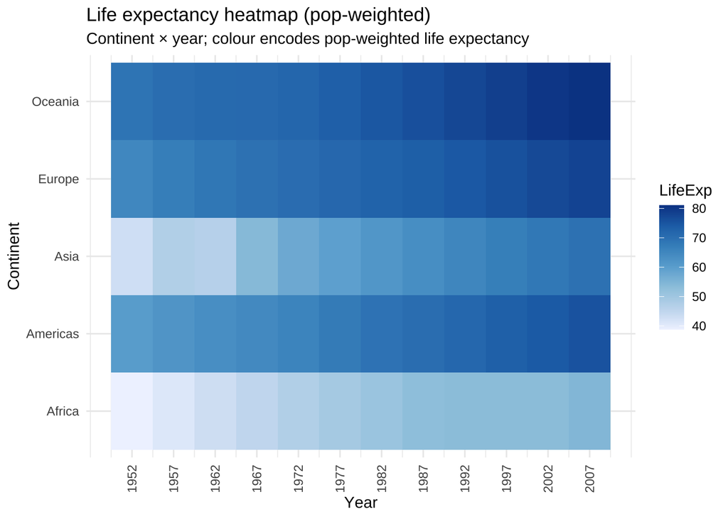

```r
# ==============================================================================
# 基础：热力图（continent × year → pop-weighted lifeExp）
# 目标：用颜色编码展示“时间×大洲”的长期模式（深=高，浅=低）
# ==============================================================================

library(tidyverse)
library(gapminder)
library(RColorBrewer)

# ------------------------------------------------------------------------------
# 1) 数据聚合：按 continent × year 计算人口加权平均预期寿命（lifeExp_w）
#    - 加权口径：让人口规模更大的国家对洲级均值贡献更大
# ------------------------------------------------------------------------------
heat_df <- gapminder %>%
  group_by(continent, year) %>%
  summarise(
    lifeExp_w = sum(lifeExp * pop, na.rm = TRUE) / sum(pop, na.rm = TRUE),
    .groups = "drop"
  )

# ------------------------------------------------------------------------------
# 2) 绘图：热力图主体使用 geom_tile()
#    - x = year（连续年份轴），y = continent（分类轴）
#    - fill = lifeExp_w（连续色标：浅→深表示低→高）
# ------------------------------------------------------------------------------
ggplot(heat_df, aes(x = year, y = continent, fill = lifeExp_w)) +
  geom_tile() +

  # x 轴：强制显示每一年刻度（年份多时需旋转以避免重叠）
  scale_x_continuous(breaks = sort(unique(heat_df$year))) +

  # 连续色标：RColorBrewer 顺序色盘（Blues）
  # direction = 1：低=浅，高=深（符合“数值越高越深”的直觉编码）
  scale_fill_distiller(
    palette = "Blues",
    direction = 1,
    name = "LifeExp"
  ) +

  # 文本信息：标题与轴标签（保持简洁，突出“模式”）
  labs(
    title = "Life expectancy heatmap (pop-weighted)",
    subtitle = "Continent × year; colour encodes pop-weighted life expectancy",
    x = "Year",
    y = "Continent"
  ) +

  # 主题：最小化背景干扰；旋转年份标签以保证可读性
  theme_minimal() +
  theme(
    axis.text.x = element_text(angle = 90, vjust = 0.5, hjust = 1)
  )
```

#### **图形解读：如何读这张热力图（Heatmap）？**

> 热力图的核心语义是**“位置=类别/时间，颜色=数值强度”**。

阅读时建议按三步走：

- **① 看纵向（同一大洲）**：  
  沿着某一行从左到右观察颜色变化，可判断该洲预期寿命是否**持续上升**、是否出现**阶段性加速/放缓**。
- **② 看横向（同一年）**：  
  固定某一年比较各行的颜色深浅，可识别不同大洲在该年份的**水平分层**（谁更高/谁更低）。
- **③ 看“梯度”与“对比”**：  
  若整体颜色随时间逐渐变深，通常提示**全球普遍改善**；若某些大洲长期偏浅或变化更慢，则提示**区域差异与不均衡**仍然显著。

解释口径：图中数值为**人口加权平均**（pop-weighted mean），因此大人口国家对洲/全球水平的贡献更大，更接近“总体平均”的统计含义。

进阶 · 代码实战

基础热力图更偏向“洲 × 年”的总体趋势，会把洲内差异平均掉。本节将视角下沉到**国家—年份**尺度，并用相对指数刻画“各国在每一年相对世界平均水平的偏离程度”。指数口径为：

$$\text{Index}_{c,t}=\frac{\text{lifeExp}_{c,t}}{\overline{\text{lifeExp}}_{world,t}}\times
100$$

其中 `Index = 100` 表示该国与当年世界平均一致。

**代码逻辑**：

Step 1 **构造世界基准：按年计算人口加权世界均值**  
先对 `gapminder` 按 `year` 分组，计算世界人口加权平均预期寿命 `world_lifeExp_w`：  
`world_lifeExp_w = Σ(lifeExp × pop) / Σ(pop)`  
该序列作为每一年统一的对照基准（避免小国对世界均值产生不成比例影响）。

Step 2 **生成国家指数：按年对齐基准并计算 Index（World=100）**  
将 `world_year` 通过 `left_join(..., by = "year")` 并入国家层数据，使每个国家—年份记录都能匹配同年的世界基准；随后计算：  
`index = lifeExp / world_lifeExp_w * 100`  
从而得到“同年可比”的相对水平指标。

Step 3 **确定 y 轴顺序：同洲相邻 + 洲内稳定排序**  
为保证读图时“同洲国家聚集”，先按 `continent × country` 汇总跨年平均指数 `index_mean`，再按  
`arrange(continent, desc(index_mean))`  
生成 `country_order`；最后将 `country` 转为按该顺序的因子。  
这一策略用“跨年均值”作为排序依据，减少国家名次随年份波动造成的视觉跳动。

Step 4 **固定图例关键刻度：保留多个刻度并强制包含 100**  
使用 `pretty(index, n = 5)` 生成连续色标的主刻度，并将 `100` 合并进刻度集合：  
`brks <- sort(unique(c(pretty(...), 100)))`  
确保图例中始终出现 “World=100” 的基准刻度，同时保留其他数值刻度用于判读梯度。

Step 5 **绘制热力图主体：tile 编码指数 + 分面聚合洲块**  
用 `geom_tile()` 将每个国家—年份网格单元填充为 `index`；  
再用 `facet_grid(continent ~ ., scales = "free_y", space = "free_y")` 将国家按大洲分块显示，使同洲国家自然聚合且各洲块高度自适应。

Step 6 **颜色编码：发散色带以 100 为中点突出“偏离”**  
使用 `scale_fill_gradient2(midpoint = 100)` 建立发散色标：  
- `< 100`：低于世界平均（低端色）  
- `≈ 100`：接近世界平均（白色）  
- `> 100`：高于世界平均（高端色）  
并将 `breaks = brks` 写入色标，使图例既包含基准 `100`，也保留判读所需的多刻度。

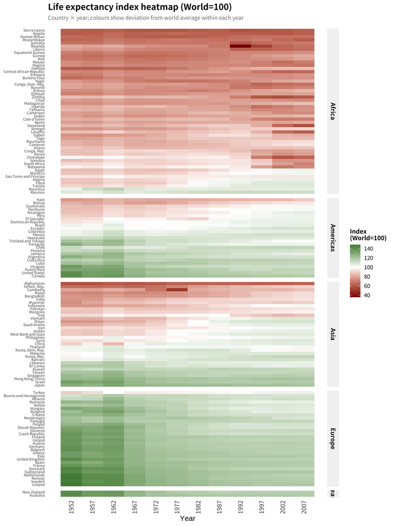

```r
# ==============================================================================
# 进阶：Country × Year 相对指数热力图（World=100）
# 目标：比较“各国随时间相对世界平均的偏离程度”
# 口径：Index = lifeExp / world(pop-weighted) × 100；100 表示当年世界平均
# ==============================================================================

library(tidyverse)
library(gapminder)
library(showtext)

# 字体：统一中文渲染
font_add_google(name = "Noto Sans SC", family = "my_font")
showtext_auto()
options(scipen = 9999)

# 1) 世界基准：按年计算人口加权世界平均 lifeExp
world_year <- gapminder %>%
  group_by(year) %>%
  summarise(
    world_lifeExp_w = sum(lifeExp * pop, na.rm = TRUE) / sum(pop, na.rm = TRUE),
    .groups = "drop"
  )

# 2) 国家指数：对齐同年世界基准并计算指数（World=100）
heat_country <- gapminder %>%
  left_join(world_year, by = "year") %>%
  mutate(index = lifeExp / world_lifeExp_w * 100)

# 3) y 轴排序：同洲相邻；洲内按跨年平均指数降序（提升整体稳定性）
country_order <- heat_country %>%
  group_by(continent, country) %>%
  summarise(index_mean = mean(index, na.rm = TRUE), .groups = "drop") %>%
  arrange(continent, desc(index_mean)) %>%
  pull(country)

heat_country <- heat_country %>%
  mutate(
    country   = factor(country, levels = country_order),
    continent = factor(continent)
  )

# 4) 图例刻度：自动生成主刻度，并强制包含 100（世界基准线）
brks <- sort(unique(c(pretty(heat_country$index, n = 5), 100)))

# 5) 出图：热力图 + 洲分面
ggplot(heat_country, aes(x = year, y = country, fill = index)) +
  geom_tile() +
  scale_x_continuous(breaks = sort(unique(heat_country$year))) +
  scale_fill_gradient2(
    low = "darkred",
    mid = "white",
    high = "darkgreen",
    midpoint = 100,
    breaks = brks,
    name = "Index\n(World=100)"
  ) +
  facet_grid(continent ~ ., scales = "free_y", space = "free_y") +
  labs(
    title = "Life expectancy index heatmap (World=100)",
    subtitle = "Country × year; colours show deviation from world average within each year",
    x = "Year",
    y = NULL
  ) +
  theme_minimal(base_size = 12) +
  theme(
    # 字体统一
    plot.title    = element_text(family = "my_font", face = "bold", size = 14, hjust = 0),
    plot.subtitle = element_text(family = "my_font", size = 9, color = "grey50",
                                 face = "italic", margin = margin(b = 12)),
    axis.text     = element_text(family = "my_font", size = 10),
    strip.text    = element_text(family = "my_font", face = "bold", size = 10),

    # 版面细节
    axis.text.x   = element_text(angle = 90, vjust = 0.5, hjust = 1),
    axis.text.y   = element_text(size = 6),
    strip.background = element_rect(fill = "grey95", colour = NA),
    panel.grid    = element_blank(),

    legend.position = "right",
    legend.text     = element_text(family = "my_font", size = 9),
    legend.title    = element_text(family = "my_font", size = 10, face = "bold")
  )
```

#### **课外教程参考**

- **热力图**：[R Graph Gallery · Levelplot / Heatmap with ggplot2](https://www.r-graph-gallery.com/79-levelplot-with-ggplot2.html)
- **相关性热力图**：[R Graph Gallery · Correlation matrix with ggplot2](https://r-graph-gallery.com/correlation-matrix.html)
- **日历热力图**：[Rigor Data Solutions · Yearly Calendar Heatmap in R](https://www.rigordatasolutions.com/post/visualizing-time-how-to-build-a-yearly-calendar-heatmap-in-r)

**© 华东师范大学 社会发展学院 人口研究所** | [**DAWN 研究组**](https://dawn-ecnu.github.io) | yzliu@soci.ecnu.edu.cn

课程负责人：刘贇喆 本章作者：刘贇喆 | 蒋娴静

最后更新：2026年03月19日 构建环境：R version 4.5.2 (2025-10-31)

[CC BY-NC-SA 4.0](https://creativecommons.org/licenses/by-nc-sa/4.0/deed.zh) 回到顶部

## **4.0 学术可视化规范**

### **4.0 学术制图规范**

重点

**学术**语境下的数据可视化更强调**准确性**与**可解释性**，其根本评价标准并非在“图是否好看” （当然，在规范的基础上进行美化会很加分），而在于图形是否能够以*清晰*且*可核查*的方式表达数据结构与比较关系。

即使图形在视觉上精致，若存在尺度误导、变量含义不清或配色语义错误等问题，也会削弱证据表达的可信度，并增加读者理解成本。

因此，本节整理一套可操作的**制图规范框架**，用于在每次完成图形后进行系统性核查 （暂不涉及下一章的地图制图规范）

> 目标 将“规范优先”作为出图的第一原则，在保证表达准确与比较有效的基础上，再讨论版式优化与视觉美化。

#### **语义匹配：图形类型必须“对得上数据”**

- **数据类型需与图形编码一致**：
  - **连续 × 连续**:  
    散点图 / 折线图（横轴需具备自然顺序，如时间） / 二维密度图（样本量较大时更稳健）
  - **类别 × 连续**:  
    柱状图（均值/总量/比例） / 箱线图（分布与离群） / 小提琴图（密度轮廓） / 条带图（抖动散点；直接呈现观测点）
  - **类别 × 类别**:  
    列联表可视化（比例热力图/马赛克图） / 分组(或堆叠)柱状图（比例对比） / 网络图（关系型数据；后续章节将介绍）
  - **单变量分布**:  
    直方图（频数/密度） / 核密度曲线（连续轮廓） / QQ 图（正态性检验）
- **常见“错误用法”需避免**：
  - 用折线图连接**无序类别**会制造“趋势”幻觉。
  - 用面积堆叠图比较**子类别的精确大小差异**需谨慎（堆叠基线不一致，跨组不易对齐）。
  - 用柱状图表达**连续变量的分布形态**并直接把柱高解读为“密度”（直方图需明确分箱与统计口径）。
  - 将存在**缺失/中断**的时间序列用折线强行连通，可能暗示不存在的连续变化（应断线或标注缺测）。

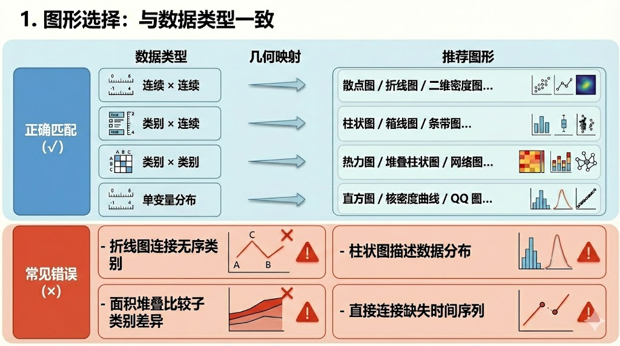

Figure 3.7. 数据要与图形匹配

#### **可比性：尺度一致**

- **坐标尺度需一致（尤其是多图/多面板对比）**：
  - 当比较的是同一指标（或同一单位/同一口径）时，应尽量保持相同 `ylim` / `xlim`，避免**“视觉比例”**替代真实差异。
  - 尤其需要避免不同图使用不同起点或截断范围（例如一图从 `0` 起、另一图从 `50` 起），这会显著放大或压缩差异，造成误读。
- **分面与组图的尺度策略**：
  - 若结论依赖“跨组比较”，优先采用**共享坐标尺度**（常见默认分面策略），使各面板可直接对齐。
  - 仅在强调“组内形态”而非“组间水平”时才考虑 `free_y` / `free_x`；一旦使用，应明确标注（例如“各面板坐标范围不同”）。
- **时间维度的对齐**：
  - 同一时间轴上的刻度与间隔应一致；避免在不同图中更改 break 规则，导致读者无法对齐关键年份与阶段。

#### **对比图的“红线”**

凡涉及**“比较”**，首先必须保证尺度可比。  
坐标起点、范围与刻度间距一旦不一致，读者的判断容易被视觉比例牵引，从而偏离真实差异。

#### **颜色规范：色带选择**

下一节详细介绍

- **按数据类型匹配色带**：
  - **连续变量**（continuous）：  
    使用**顺序色带**（由浅入深）编码**“由小到大”**的数值梯度，通常遵循深色 = 更大值的直觉规则。  
    例如 `Blues`：浅蓝表示较低水平，深蓝表示较高水平。
  - **相对偏离/指数**（diverging）：  
    使用**发散色带**（颜色由中心向两端扩散并加深），并将**基准值**设为浅色中点（常用白色或浅色），向两侧分别表示“低于基准”与“高于基准”的方向性偏离。  
    例如：深蓝 — 白 — 深红。

    > 关键 图例中需显示基准刻度与中点数值（如 0、100）
  - **分类变量**（categorical）：  
    使用**离散色板**（类别之间应清晰可区分）。

    > 当图形同时需要表达**“组间对比 + 组内构成”**时，可采用**分组同色系**策略：
    > - 不同“大组”用不同色系区分；
    > - 同一“大组”内部的子类别用同色系的明暗/饱和度变化表示（提示隶属关系，同时保持可区分）。

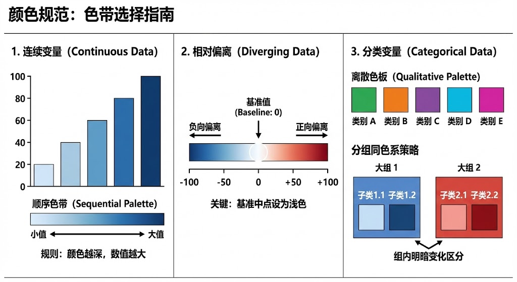

Figure 3.8. 数据类型与配色参考

- **保持颜色语义一致**：
  - 同一变量在不同图中应避免出现**“深浅含义反转”**（例如某图深色=高值、另一图深色=低值），以免读者在**跨图对比**时产生系统性误读。
  - 对**连续变量**，应在整篇研究内遵循一致的“方向约定”：通常采用浅色=低值、深色=高值（即使更换不同色系，也不改变深浅含义）。
  - 对**分类变量**，同一类别在不同图中应尽量保持同一颜色（例如某一组别在图 1 为紫色，则在图 2 仍为紫色）；若必须更换色板，应确保读者可通过图例快速确认映射，避免“同名类别换色”造成误读。
  - 当存在“分组中的分组”（如大组=大洲，子组=国家）时，可采用**同色系分层**：大组使用同一色相锚定，子组用明暗/饱和度区分，以同时维持组间可辨识与组内一致性。

> **多通道编码：不要只靠颜色传达信息**：  
> - 在投影展示、灰度打印或存在色觉差异的场景下，可叠加其他视觉通道增强区分度，例如不同**点形**（散点图）、不同**线型**（折线图）或**纹理/图案填充**（柱状图/面积图），从而提升图形的稳健性与可读性。

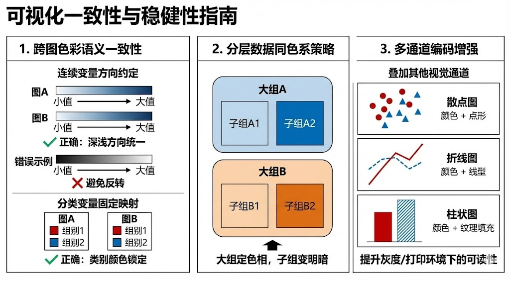

Figure 3.9. 可视化的一致性与稳健性

#### **布局策略：减少堆叠与遮挡，优先“分层表达”**

- **组别/变量过多时，优先使用分面（facet）**：  
  当同一坐标系叠加过多组别（多条折线/多类散点/多组分布）时，图形容易退化为“线团/点团”。  
  更稳健的做法是用 `facet_wrap()` / `facet_grid()` 分层展示，使单幅子图的信息密度可控。
- **控制遮挡（overlap）**：  
  出现明显重叠时，可先用 `alpha`、点大小、减少标签（只标关键点）缓解；  
  对高密度散点可改用二维分箱或密度表达（如二维计数热力图/密度等高线）。
- **当目标是“比较”，组图通常优于堆叠**：  
  若关注组间差异而非构成结构，可用**共享尺度**的分面或并排子图提升可比性（例如按性别分面）。
- **堆叠图的适用边界需明确**：  
  堆叠柱适合表达“总量 + 构成”；但若需要比较子类别在不同主类别间的大小，通常更适合改用**分组柱状图**或**分面**（避免堆叠基线变化带来的误读）。

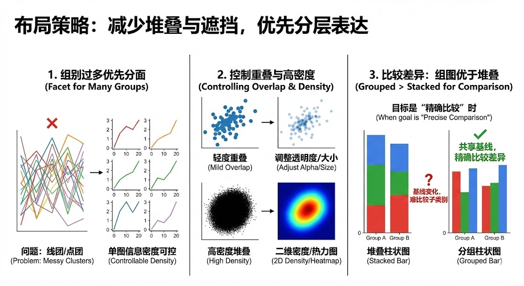

Figure 3.10. 可视化策略

#### **坐标与文本规范**

- **轴标签写清楚**：  
  轴标签应同时说明**变量含义**、**单位**与**尺度处理**（如对数/标准化/指数）。
  - 例：`log10(GDP per capita, USD)` 明确指出对数变换与计量单位，避免读者误以为是线性尺度。
- **保持刻度与范围可比性**：  
  分面或组图用于对比时，优先保持共享的 `xlim/ylim` 与刻度规则，确保视觉比例一致。  
  若必须使用自由尺度（如 `free_y/free_x`），应在副标题或图注中明确提示“尺度不一致”，避免跨图误读。
- **术语标注要“可读”，避免缩写/编码直出**：  
  代码变量名、缩写与分组编码（如 `lifeExp_w`、`NO2`、`CI`、`Q5`、`A1`）属于计算口径或内部标识，图中应转换为读者可理解的标签（必要时补充单位/分组规则）。
  - `lifeExp_w` → 人口加权平均预期寿命
  - `NO2` → 二氧化氮浓度
  - `CI Q5` → Carstairs 指数：最高贫困五分位
  - `BFL_den_cat1` → 棕地密度分组
- **字体体系统一**：  
  图内文字（标题、坐标轴、刻度、图例、标注） 应尽量保持**字体、字号与颜色**一致（同一论文/同一章节尤其如此）。

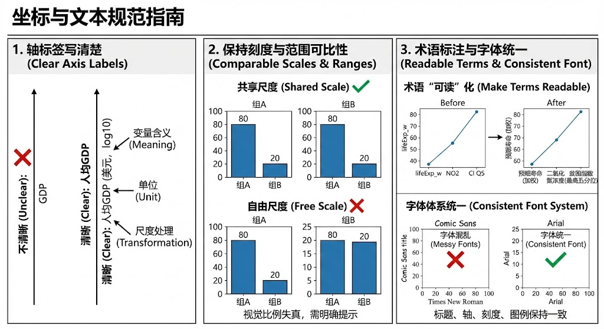

Figure 3.11. 坐标文本规范

#### **信息密度适中，保持易读性**

- **图片标题与标注**：重要  
  在确保图片有注释/说明的情况下 （如 Figure. x ‘…’），在最终可视化的成果上可以去掉 **标题** 和 **副标题**，保持图片台头整洁。不需要重复下方注释文字在标题中 投稿时常用
- **控制视觉噪声**：  
  弱化非必要的背景元素（如过强网格线、复杂底纹），避免**装饰性** 3D/阴影等效果干扰数值读数与结构判断。
- **一图聚焦核心任务**：  
  单幅图形宜服务于 **1–2** 个主要目的（趋势、对比、结构或分布）；当信息维度过多，应优先使用分面或组图分层表达，避免“所有信息挤在一张图里”。
- **复杂度不等于信息增量**：  
  图形设计应以降低理解成本为准则；若读者需要反复对照图例、坐标或注释才能读懂，则应考虑简化编码或拆分表达。
- **标注“少而准”**：  
  仅标注关键点位（极值、拐点、阈值、显著差异）；避免对每个点/每个类别都加标签造成遮挡与阅读负担。
- **图例与编码保持最小化**：  
  只保留必要图例项；若图例与坐标轴信息重复（例如 x 轴已写明类别），可移除或合并，以减少认知切换。
- **留白用于组织，而非浪费**：  
  通过合理边距与对齐提升层次感（标题—图体—图例分区清晰）；避免图例挤压图体或信息贴边导致“读图压迫感”。

思考

#### **投稿提醒**

**© 华东师范大学 社会发展学院 人口研究所** | [**DAWN 研究组**](https://dawn-ecnu.github.io) | yzliu@soci.ecnu.edu.cn

课程负责人：刘贇喆 本章作者：刘贇喆 | 蒋娴静

最后更新：2026年03月19日 构建环境：R version 4.5.2 (2025-10-31)

[CC BY-NC-SA 4.0](https://creativecommons.org/licenses/by-nc-sa/4.0/deed.zh) 回到顶部

## **5.0 可视化美化**

### **5.0 制图美化与颜色选择**

> 前一节已强调：学术图形的首要评价标准是准确与可解释。因此，所有“美化”都应以规范出图为前提。

在满足规范的基础上，适度的**“美化”**属于额外加分项：它能够降低读图成本、强化信息层次，并提升版面观感。  
(本节聚焦“非地图类可视化”的美化策略)

#### **教师经验之谈：美化的现实价值**

在大多数**数据驱动研究**中，高质量的可视化不仅传递研究结果，也传递“研究打磨程度”。

当规范前提已满足时，版式更克制、配色更稳健、层次更清楚的图形，往往更容易获得读者与评审的注意，并**提升整体呈现的专业感**。

#### **配色选择：科研可视化的功能性艺术**

##### **配色的重要性**

- **提升呈现的专业度**：稳定、克制的配色能减少“随意感”，并降低高饱和原色带来的视觉刺激与误导风险。  
  (一般不建议大面积使用纯红/纯绿等高饱和颜色；应优先选择可读性更稳健的色板)
- **强化信息结构**：配色不仅用于区分，也用于表达**层级**与**方向**。合理的明度/冷暖安排可突出重点，帮助读者更快抓住主结论。
- **降低认知负荷**：直观的颜色编码能缩短“识别分组 → 对比差异 → 形成判断”的阅读路径。
- **保证跨图一致性**：同一研究中**配色体系稳定**，有助于跨图对照与记忆，减少读者反复适应的成本。

##### **什么是“好的科研配色”**

###### **1）语义匹配：色带与数据类型一致**

- **顺序色带**：用于**连续变量**。  
  颜色随数值**单调变化**（常见为浅 → 深），并尽量遵循深色 = 更大值的方向约定。  
  (不建议使用“彩虹色带”，其亮度跳跃容易制造伪边界，干扰梯度判断)
- **发散色带**：用于**存在基准**的数据（如差值、指数、相对偏离）。  
  基准值设为浅色中点（常用白/浅灰），两侧用不同色相表示低于/高于基准。  
  (常见形式：深蓝 — 白 — 深红；图例应明确标出中点刻度，如 0 或 100)
- **离散色板**：用于**分类变量**。  
  类别之间需可区分，同时避免某一颜色过于“抢眼”导致视觉权重失衡。  
  (当存在“大组 + 子组”结构，可采用“组间不同色相 + 组内同色系明暗”以提示隶属关系)

###### **2）稳健可读：不同阅读场景下仍可理解**

- **色觉差异与灰度输出**：尽量避免红–绿直接对立；在灰度打印/投影场景下，仍应保持明度差异可辨。
- **感知均匀（连续色带）**：优先选用感知更均匀的色带（如 `viridis` 系列），使视觉变化更贴近数值变化。

###### **3）数量克制：颜色不是越多越好**

- 分类颜色过多会显著提高认知负担；当类别超出可读阈值时，优先考虑：
  - **分面/组图分层**；或
  - 合并次要类别为 **Other**。

> 有研究显示：人类短时记忆难以高效处理超过 7 种以上的分类颜色  
> 建议可视化图中的颜色**尽量**不要超过**7**种 （分类数据）